# Fit Index

### Types of Fit Index

- Abosulte Fit Indices - ($\chi^2$, GFI, AGFI, AIC, BIC, RMR, SRMR) - Absolute fit indices do not use an alternative model as a base for comparison. They are simply derived from the fit of the obtained and implied covariance matrices .
- Relative Fit Indices - (IIFL, TLI, NFI) - Relative fit indices compare a chi-square for the model tested to one from a so-called null model (also called a “baseline” model or “independence” model). The null model is a model in which all measured variables are uncorrelated (there are no latent variables).
- Parsimonious Fit Indices - (PGFI, PNFI, PCFI) - Parsimony-corrected fit indices are relative fit indices that are adjustments to most of the fit indices mentioned above. The adjustments are to penalize models that are less parsimonious, so that simpler theoretical processes are favored over more complex ones.
- Non-centrality Based Indices - (RMSEA, CFI, RNI,CI)

The various overall fit indices which have been proposed tend to fall into two categories:

- those that simply describe goodness of fit,
- and those that involve considerations of parsimony (i.e., that take into account the number of unknowns used to achieve that fit). A model reaching a particular level of fit while solving for fewer free parameters would show as superior on an index of the latter kind.

```r
library(lavaan)
```

```r
library(semPlot)
library(psych)
library(psychTools)

test3 <- lavaan::HolzingerSwineford1939
test4 <- lavaan::PoliticalDemocracy


View(test3)

str(test4)
```

```
## 'data.frame':    75 obs. of  11 variables:
##  $ y1: num  2.5 1.25 7.5 8.9 10 7.5 7.5 7.5 2.5 10 ...
##  $ y2: num  0 0 8.8 8.8 3.33 ...
##  $ y3: num  3.33 3.33 10 10 10 ...
##  $ y4: num  0 0 9.2 9.2 6.67 ...
##  $ y5: num  1.25 6.25 8.75 8.91 7.5 ...
##  $ y6: num  0 1.1 8.09 8.13 3.33 ...
##  $ y7: num  3.73 6.67 10 10 10 ...
##  $ y8: num  3.333 0.737 8.212 4.615 6.667 ...
##  $ x1: num  4.44 5.38 5.96 6.29 5.86 ...
##  $ x2: num  3.64 5.06 6.26 7.57 6.82 ...
##  $ x3: num  2.56 3.57 5.22 6.27 4.57 ...
```

```r
model2 <- '

# factors

           eco60 =~ x1 + x2 + x3

           pol60 =~ y1 + y2 + y3 + y4

           pol65 =~ y5 + y6 + y7 + y8

# regressions

          pol60 ~ eco60

          pol65 ~ eco60 + pol60 '


fit1 <- sem(model= model2, data = test4)

fitMeasures(fit1, fit.measures = "all")
```

```
##                  npar                  fmin                 chisq
##                25.000                 0.483                72.462
##                    df                pvalue        baseline.chisq
##                41.000                 0.002               730.654
##           baseline.df       baseline.pvalue                   cfi
##                55.000                 0.000                 0.953
##                   tli                  nnfi                   rfi
##                 0.938                 0.938                 0.867
##                   nfi                  pnfi                   ifi
##                 0.901                 0.672                 0.954
##                   rni                  logl     unrestricted.logl
##                 0.953             -1564.959             -1528.728
##                   aic                   bic                ntotal
##              3179.918              3237.855                75.000
##                  bic2                 rmsea        rmsea.ci.lower
##              3159.062                 0.101                 0.061
##        rmsea.ci.upper        rmsea.ci.level          rmsea.pvalue
##                 0.139                 0.900                 0.021
##        rmsea.close.h0 rmsea.notclose.pvalue     rmsea.notclose.h0
##                 0.050                 0.827                 0.080
##                   rmr            rmr_nomean                  srmr
##                 0.428                 0.428                 0.055
##          srmr_bentler   srmr_bentler_nomean                  crmr
##                 0.055                 0.055                 0.060
##           crmr_nomean            srmr_mplus     srmr_mplus_nomean
##                 0.060                 0.055                 0.055
##                 cn_05                 cn_01                   gfi
##                59.937                68.225                 0.854
##                  agfi                  pgfi                   mfi
##                 0.765                 0.531                 0.811
##                  ecvi
##                 1.633
```

```r
model3 <- '
  # measurement model
    ind60 =~ x1 + x2 + x3
    dem60 =~ y1 + y2 + y3 + y4
    dem65 =~ y5 + y6 + y7 + y8
  # regressions
    dem60 ~ ind60
    dem65 ~ ind60 + dem60
  # residual correlations
    y1 ~~ y5
    y2 ~~ y4 + y6
    y3 ~~ y7
    y4 ~~ y8
    y6 ~~ y8'


fit2 <- sem(model = model3, data = test4)

fitmeasures(fit2, baseline.model = fit1, output = "matrix") # this
```

```
##
## npar                     31.000
## fmin                      0.254
## chisq                    38.125
## df                       35.000
## pvalue                    0.329
## baseline.chisq           72.462
## baseline.df              41.000
## baseline.pvalue           0.002
## cfi                       0.901
## tli                       0.884
## nnfi                      0.884
## rfi                       0.384
## nfi                       0.474
## pnfi                      0.405
## ifi                       0.917
## rni                       0.901
## logl                  -1547.791
## unrestricted.logl     -1528.728
## aic                    3157.582
## bic                    3229.424
## ntotal                   75.000
## bic2                   3131.720
## rmsea                     0.035
## rmsea.ci.lower            0.000
## rmsea.ci.upper            0.092
## rmsea.ci.level            0.900
## rmsea.pvalue              0.611
## rmsea.close.h0            0.050
## rmsea.notclose.pvalue     0.114
## rmsea.notclose.h0         0.080
## rmr                       0.276
## rmr_nomean                0.276
## srmr                      0.044
## srmr_bentler              0.044
## srmr_bentler_nomean       0.044
## crmr                      0.049
## crmr_nomean               0.049
## srmr_mplus                0.045
## srmr_mplus_nomean         0.045
## cn_05                    98.970
## cn_01                   113.803
## gfi                       0.923
## agfi                      0.854
## pgfi                      0.489
## mfi                       0.979
## ecvi                      1.335
```

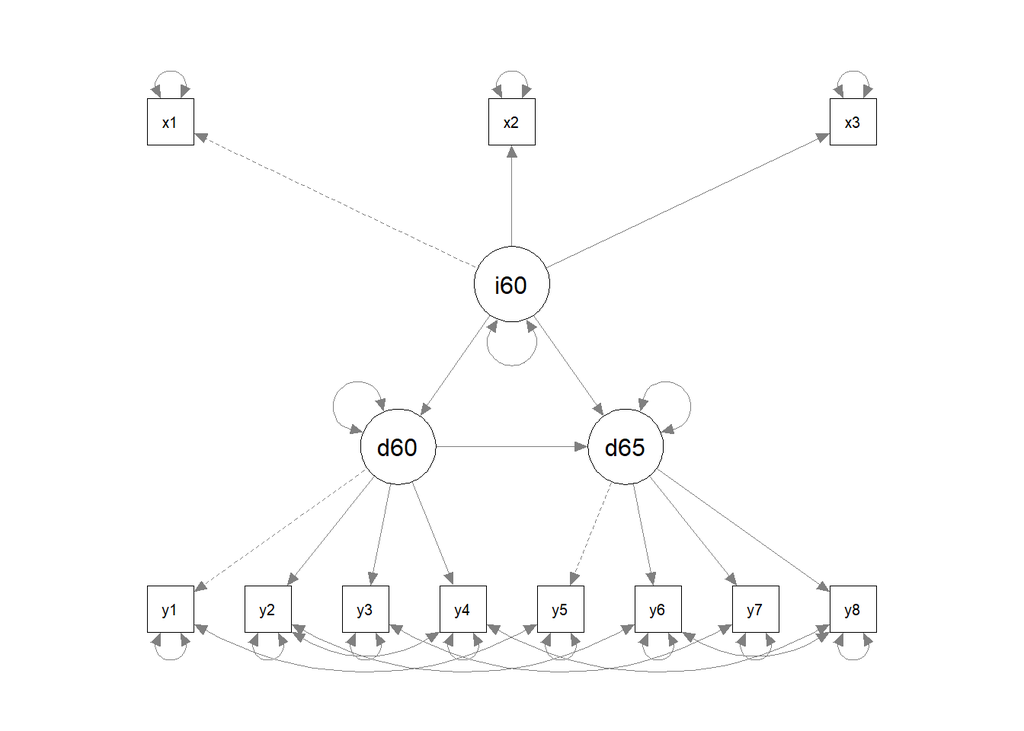

```r
semPaths(fit2)
```

```r
anova(fit1, fit2)
```

```
##
## Chi-Squared Difference Test
##
##      Df    AIC    BIC  Chisq Chisq diff   RMSEA Df diff Pr(>Chisq)
## fit2 35 3157.6 3229.4 38.125
## fit1 41 3179.9 3237.9 72.462     34.336 0.25094       6  5.792e-06 ***
## ---
## Signif. codes:  0 '***' 0.001 '**' 0.01 '*' 0.05 '.' 0.1 ' ' 1
```